# Lab6.qmd

# Question 4: Build Your Own

## Data Splitting

### Set a Seed

```r
set.seed(123456)
```

### Create an initial split with 75% used for training and 25% for testing

```r
resample_split <- initial_split(camels, prop = 0.75)
```

### Extract your training and testing sets

```r
train_camels <- training(resample_split)
glimpse(train_camels)
```

```
Rows: 503
Columns: 59
$ gauge_id             <chr> "01548500", "03357350", "01451800", "02118500", "…
$ p_mean               <dbl> 3.153346, 3.220156, 3.503207, 3.497721, 3.508962,…
$ pet_mean             <dbl> 2.271782, 2.529923, 2.418851, 2.854343, 2.566778,…
$ p_seasonality        <dbl> 0.17916389, 0.19294173, 0.10670771, 0.06450132, 0…
$ frac_snow            <dbl> 0.202088630, 0.070238198, 0.128362666, 0.04137083…
$ aridity              <dbl> 0.7204355, 0.7856524, 0.6904675, 0.8160581, 0.731…
$ high_prec_freq       <dbl> 18.10, 22.60, 23.80, 22.35, 21.45, 22.20, 21.55, …
$ high_prec_dur        <dbl> 1.120743, 1.167959, 1.233161, 1.238227, 1.194986,…
$ high_prec_timing     <chr> "jja", "jja", "son", "mam", "mam", "djf", "mam", …
$ low_prec_freq        <dbl> 221.00, 253.55, 254.25, 250.15, 250.60, 257.35, 2…
$ low_prec_dur         <dbl> 3.177570, 4.183993, 4.188633, 4.556466, 4.111567,…
$ low_prec_timing      <chr> "son", "son", "son", "son", "son", "son", "son", …
$ geol_1st_class       <chr> "Siliciclastic sedimentary rocks", "Mixed sedimen…
```

[output cut: 46 more lines]

```r
test_camels <- testing(resample_split)
glimpse(test_camels)
```

```
Rows: 168
Columns: 59
$ gauge_id             <chr> "01055000", "01121000", "01134500", "01139800", "…
$ p_mean               <dbl> 3.494183, 3.719591, 3.467413, 3.303515, 3.420860,…
$ pet_mean             <dbl> 2.093235, 2.301408, 2.091698, 2.127185, 2.157740,…
$ p_seasonality        <dbl> 0.167229041, 0.004098324, 0.228672353, 0.22557908…
$ frac_snow            <dbl> 0.30604885, 0.15422715, 0.28058209, 0.26232897, 0…
$ aridity              <dbl> 0.5990628, 0.6187263, 0.6032446, 0.6439157, 0.630…
$ high_prec_freq       <dbl> 19.15, 21.50, 15.85, 19.45, 19.05, 19.95, 20.40, …
$ high_prec_dur        <dbl> 1.167683, 1.197772, 1.152727, 1.164671, 1.133929,…
$ high_prec_timing     <chr> "son", "son", "jja", "jja", "jja", "son", "son", …
$ low_prec_freq        <dbl> 224.85, 241.70, 201.10, 225.55, 225.15, 226.35, 2…
$ low_prec_dur         <dbl> 3.378663, 3.721324, 2.842403, 3.278343, 3.315906,…
$ low_prec_timing      <chr> "mam", "son", "mam", "mam", "mam", "son", "son", …
$ geol_1st_class       <chr> "Siliciclastic sedimentary rocks", "Metamorphics"…
```

[output cut: 46 more lines]

### Build a 10-fold CV dataset as well

```r
cv_folds <- vfold_cv(train_camels, v = 10)

cv_folds
```

```
#  10-fold cross-validation
# A tibble: 10 × 2
   splits           id
   <list>           <chr>
 1 <split [452/51]> Fold01
 2 <split [452/51]> Fold02
 3 <split [452/51]> Fold03
 4 <split [453/50]> Fold04
 5 <split [453/50]> Fold05
 6 <split [453/50]> Fold06
 7 <split [453/50]> Fold07
 8 <split [453/50]> Fold08
 9 <split [453/50]> Fold09
10 <split [453/50]> Fold10
```

## Recipe

### Define a formula you want to use to predict logQmean

```r
formula <- logQmean ~ p_mean + aridity + high_prec_dur
```

### Build a recipe that you feel handles the predictors chosen well

```r
train_camels <- na.omit(train_camels)

    # Create a recipe to preprocess the data
rec <-  recipe(logQmean ~ p_mean + aridity + high_prec_dur, data = train_camels) %>%
      # Log transform the predictor variables (aridity and p_mean)
  step_log(all_predictors()) %>%
      # Add an interaction term between aridity and p_mean
      # step_interact(terms = ~ aridity:p_mean) |>
      # Drop any rows with missing values in the pred
  step_naomit(all_predictors(), all_outcomes()) %>%
  step_zv(all_predictors())

    # Prep and bake data
rec_prep <- prep(rec, training = train_camels)
baked_data <- bake(rec_prep, new_data = NULL)

    # Make sure my data doesn't have NA or inf values.
sum(is.na(baked_data)) # Should return 0
```

```
[1] 0
```

```r
sum(is.infinite(as.matrix(baked_data))) # Should return 0
```

```
[1] 0
```

## Define 3 Models

### Define a random forest model using the rand_forest function & Set the engine to ranger and the mode to regression

```r
Q4_rf_model <- rand_forest() %>%
  set_engine("ranger") %>%
  set_mode("regression")
```

### Define two other models of your choice

```r
Q4_lm_model <- linear_reg() %>%
  set_engine("lm") %>%
  set_mode("regression")

Q4_gbm_model <- boost_tree() %>%
  set_engine("xgboost") %>%
  set_mode("regression")
```

## Workflow Set

### Create a workflow object, add the recipe, and add the models. Additionally, fit the models to the resamples.

```r
    # Define workflows
Q4_rf_wf <- workflow() |>
  add_recipe(rec) |>
  add_model(Q4_rf_model)

Q4_lm_wf <- workflow() |>
  add_recipe(rec) |>
  add_model(Q4_lm_model)

Q4_gbm_wf <- workflow() |>
  add_recipe(rec) |>
  add_model(Q4_gbm_model)

    # Use fit_resamples directly on the workflows
rf_results <- fit_resamples(Q4_rf_wf, resamples = cv_folds)
lm_results <- fit_resamples(Q4_lm_wf, resamples = cv_folds)
gbm_results <- fit_resamples(Q4_gbm_wf, resamples = cv_folds)
```

## Evaluation

### Use autoplot and rank_results to compare the models.

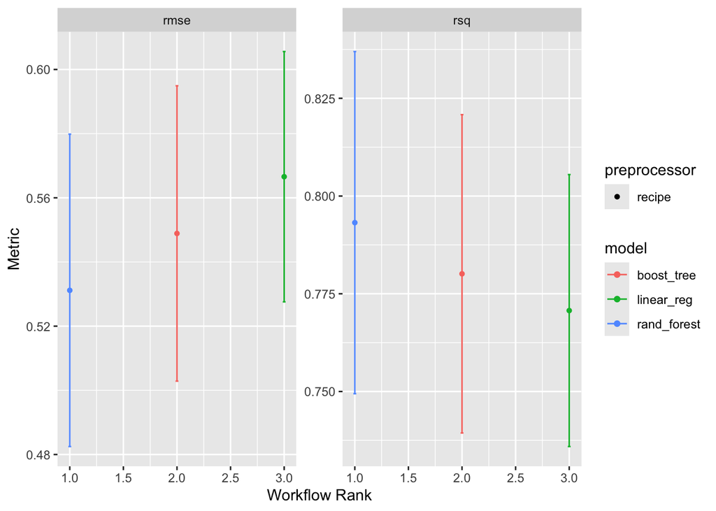

```r
wf <- workflow_set(list(rec), list(Q4_rf_model, Q4_lm_model, Q4_gbm_model)) %>%
  workflow_map('fit_resamples', resamples = camels_cv)

autoplot(wf)
```

```r
rank_results(wf, rank_metric = "rsq", select_best = TRUE)
```

```
# A tibble: 6 × 9
  wflow_id          .config .metric  mean std_err     n preprocessor model  rank
  <chr>             <chr>   <chr>   <dbl>   <dbl> <int> <chr>        <chr> <int>
1 recipe_rand_fore… Prepro… rmse    0.531  0.0296    10 recipe       rand…     1
2 recipe_rand_fore… Prepro… rsq     0.793  0.0266    10 recipe       rand…     1
3 recipe_boost_tree Prepro… rmse    0.549  0.0280    10 recipe       boos…     2
4 recipe_boost_tree Prepro… rsq     0.780  0.0248    10 recipe       boos…     2
5 recipe_linear_reg Prepro… rmse    0.567  0.0237    10 recipe       line…     3
6 recipe_linear_reg Prepro… rsq     0.771  0.0211    10 recipe       line…     3
```

### Describe what model you think is best and why!

I think that the random forest is the best model because it has the best ranked metrics for both RMSE and RSQ, indicating high coincidence in our model with the data.

## Extact and Evaluate

### Build a workflow (not workflow set) with your favorite model, recipe, and training data. Use fit to fit all training data to the model.

```r
final_workflow <- workflow() |>
  add_recipe(rec) |>
  add_model(Q4_rf_model) |>
  fit(data = train_camels)
```

### Use augment to make predictions on the test data

```r
final_workflow_data <- augment(final_workflow, new_data = camels_test)
```

### Create a plot of the observed vs predicted values with clear title, axis labels, and a compelling color scale

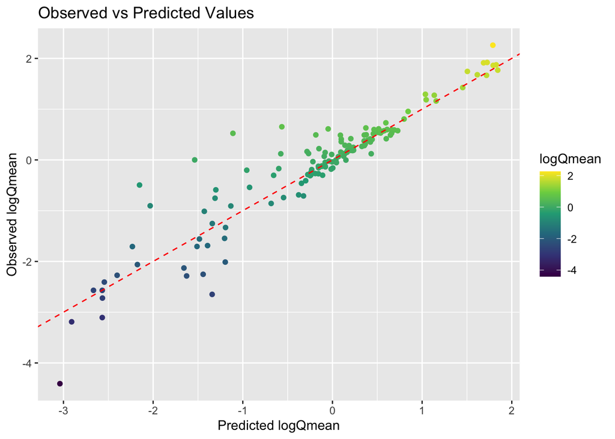

```r
ggplot(final_workflow_data, aes(x = .pred, y = logQmean, colour = logQmean)) +
  geom_point() +
  geom_abline(slope = 1, intercept = 0, color = "red", linetype = "dashed") +
  labs(title = "Observed vs Predicted Values",
       x = "Predicted logQmean",
       y = "Observed logQmean") +
  scale_color_viridis_c()
```

### Describe what you think of the results!

The results seem to be fairly accurate! The plotted points of observed versus predicted logQmean values are clustered along the 1:1 line, indicating strong accuracy of the model’s predictions. It’s awesome that I created a model that is able to predict logQmean based on the predictors I chose!